# Data Analysis report

This is a report for data analysis assignement given for the reproducible reseatch course. Begin by loading the data to be used. First unzip the data then load it:

```r
setwd("~/Coursera/RepData_PeerAssessment1")
unzip("~/Coursera/RepData_PeerAssessment1/activity.zip")
activity <- read.csv("activity.csv")
```

View the data

```r
str(activity)
```

```
## 'data.frame':    17568 obs. of  3 variables:
##  $ steps   : int  NA NA NA NA NA NA NA NA NA NA ...
##  $ date    : Factor w/ 61 levels "2012-10-01","2012-10-02",..: 1 1 1 1 1 1 1 1 1 1 ...
##  $ interval: int  0 5 10 15 20 25 30 35 40 45 ...
```

## What is the total number of steps taken per day?

```
##         date steps
## 1 2012-10-02   126
## 2 2012-10-03 11352
## 3 2012-10-04 12116
## 4 2012-10-05 13294
## 5 2012-10-06 15420
## 6 2012-10-07 11015
## 7 2012-10-09 12811
## 8 2012-10-10  9900
```

The following histogram shows the total number of steps raken each day.

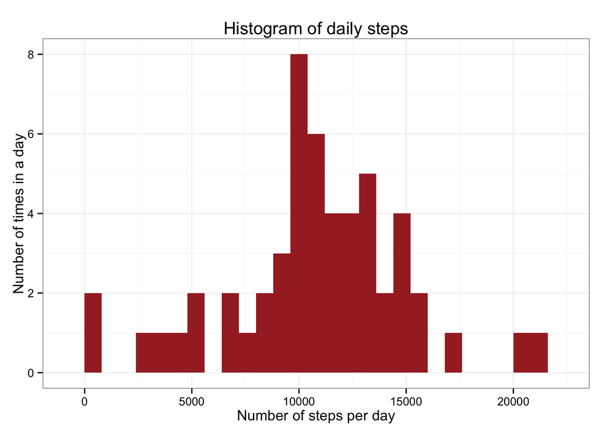

```r
library(ggplot2)
ggplot(daily.steps, aes(x=steps)) +
    geom_histogram(fill="brown",binwidth=800) +
    labs(title="Histogram of daily steps",
         x = "Number of steps per day",y="Number of times in a day") + theme_bw()
```

The median total number of steps taken per day is 10765

## What is the average daily activity pattern?

```
##   interval     steps
## 1        0 1.7169811
## 2        5 0.3396226
## 3       10 0.1320755
## 4       15 0.1509434
## 5       20 0.0754717
## 6       25 2.0943396
```

Averaged daily steps of the 5-minute interval time series plot.

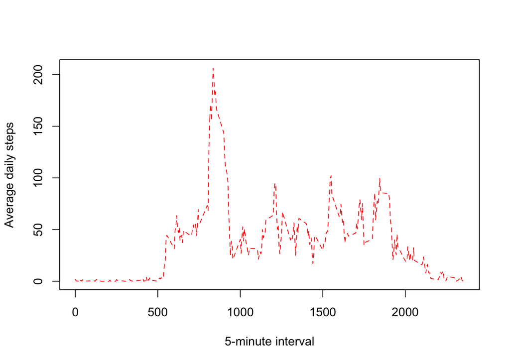

The 835-th 5-min interval contains the maximum number of steps.